# Report of the PacMAN pipeline

OBIS secretariat

30 September, 2022

# 1 PacMAN pipeline report

Congratulations! You have finished running the PacMAN pipeline. In this report you will find the information of all the main steps run with your sequences, and the statistics related to how it went.

Specifically, this is the report for the project: ARMS  
And the pipeline run: Blast_trials3.  
And the samples that were run in this analysis are:

ERR3460466  
ERR3460467  
ERR3460468  
ERR3460469  
ERR3460470  
ERR3460471

## 1.1 Quality control

Quality control of the raw samples was done so that any issues in the final analysis can possibly be traced back to issues in the original data.

Visual representation of the results of the QC on the raw data can be found in an html report in:  
results/ARMS/samples/multiqc_Blast_trials3.html  
Generally, the sequences in the samples had the following composition:

| Sample | percent duplicates | percent gc | avg sequence length | percent fails | total sequences |
| --- | --- | --- | --- | --- | --- |
| ERR3460466 \| qc \| fw | 73.8 | 38 | 306 | 36.4 | 132834 |
| ERR3460466 \| qc \| rv | 78.1 | 38 | 306 | 54.5 | 132834 |
| ERR3460467 \| qc \| fw | 75.6 | 40 | 306 | 45.5 | 266983 |
| ERR3460467 \| qc \| rv | 80.3 | 43 | 306 | 36.4 | 266983 |
| ERR3460468 \| qc \| fw | 60.5 | 38 | 306 | 45.5 | 187685 |
| ERR3460468 \| qc \| rv | 71.0 | 40 | 306 | 45.5 | 187685 |
| ERR3460469 \| qc \| fw | 63.9 | 37 | 306 | 36.4 | 136265 |
| ERR3460469 \| qc \| rv | 73.4 | 38 | 306 | 45.5 | 136265 |
| ERR3460470 \| qc \| fw | 76.7 | 39 | 306 | 45.5 | 146303 |
| ERR3460470 \| qc \| rv | 81.5 | 39 | 306 | 54.5 | 146303 |
| ERR3460471 \| qc \| fw | 64.4 | 41 | 306 | 36.4 | 180296 |
| ERR3460471 \| qc \| rv | 73.8 | 43 | 306 | 36.4 | 180296 |

## 1.2 Sequence trimming

As you can most likely see, there are several issues with the raw sequences. Therefore, the sequences were trimmed and cleaned-up prior to the analysis of sequence variants and the taxonomic composition of the samples.  
The first step of the process was to trim the samples using [Trimmomatic](http://www.usadellab.org/cms/?page=trimmomatic) (Bolger et al. 2014).  
The command that was used was:

[output not shown]

And the results for each sample in reads, and in percentages of original reads:

|  | InputReadPairs | BothSurviving | ForwardOnlySurviving | ReverseOnlySurviving | Dropped |
| --- | --- | --- | --- | --- | --- |
| ERR3460466 | 132834 | 106914 | 25920 | 0 | 0 |
| ERR3460467 | 266983 | 58680 | 208303 | 0 | 0 |
| ERR3460468 | 187685 | 69117 | 118568 | 0 | 0 |
| ERR3460469 | 136265 | 111881 | 24384 | 0 | 0 |
| ERR3460470 | 146303 | 123006 | 23297 | 0 | 0 |
| ERR3460471 | 180296 | 11111 | 169185 | 0 | 0 |

|  | BothSurviving | ForwardOnlySurviving | ReverseOnlySurviving | Dropped |
| --- | --- | --- | --- | --- |
| ERR3460466 | 80.49 | 19.51 | 0 | 0 |
| ERR3460467 | 21.98 | 78.02 | 0 | 0 |
| ERR3460468 | 36.83 | 63.17 | 0 | 0 |
| ERR3460469 | 82.11 | 17.89 | 0 | 0 |
| ERR3460470 | 84.08 | 15.92 | 0 | 0 |
| ERR3460471 | 6.16 | 93.84 | 0 | 0 |

## 1.3 Cutadapt

The next step in the process ran cutadapt on all samples (paired and unpaired results).  
The command that was used was:

[output not shown]

### 1.3.1 Paired reads

The results for all paired samples were:

|  | TotalReadPairsProcessed | Read1withPrimer | Read2withPrimer | PairsTooShort | PairsWritten | BasePairsProcessed | Read1BpProcessed | Read2BpProcessed | BasePairsWritten | Read1BpWritten | Read2BpWritten |
| --- | --- | --- | --- | --- | --- | --- | --- | --- | --- | --- | --- |
| ERR3460466 | 106914 | 106751 | 106323 | 0 | 106914 | 59389182 | 31395165 | 27994017 | 53850806 | 28620583 | 25230223 |
| ERR3460467 | 58680 | 58547 | 57605 | 142 | 58538 | 30868081 | 16415756 | 14452325 | 27812492 | 14876839 | 12935653 |
| ERR3460468 | 69117 | 68997 | 68410 | 10 | 69107 | 37560623 | 19916514 | 17644109 | 33979863 | 18118927 | 15860936 |
| ERR3460469 | 111881 | 111729 | 111076 | 0 | 111881 | 61512742 | 32830706 | 28682036 | 55722262 | 29926827 | 25795435 |
| ERR3460470 | 123006 | 122875 | 122352 | 0 | 123006 | 68388384 | 36481154 | 31907230 | 62014128 | 33287564 | 28726564 |
| ERR3460471 | 11111 | 11052 | 10378 | 1589 | 9522 | 3025935 | 1799693 | 1226242 | 2379709 | 1495646 | 884063 |

|  | Read1withPrimer | Read2withPrimer | PairsTooShort | PairsWritten | BasePairsWritten |
| --- | --- | --- | --- | --- | --- |
| ERR3460466 | 99.85 | 99.45 | 0.00 | 100.00 | 52.86 |
| ERR3460467 | 99.77 | 98.17 | 0.24 | 99.76 | 53.18 |
| ERR3460468 | 99.83 | 98.98 | 0.01 | 99.99 | 53.02 |
| ERR3460469 | 99.86 | 99.28 | 0.00 | 100.00 | 53.37 |
| ERR3460470 | 99.89 | 99.47 | 0.00 | 100.00 | 53.34 |
| ERR3460471 | 99.47 | 93.40 | 14.30 | 85.70 | 59.48 |

### 1.3.2 Unpaired reads

While for forward unpaired reads they were:

|  | TotalReadPairsProcessed | ReadwithPrimer | ReadsTooShort | ReadsWritten | BasePairsProcessed | BasePairsWritten |
| --- | --- | --- | --- | --- | --- | --- |
| ERR3460466 | 25920 | 25919 | 0 | 25917 | 1621802 | 947906 |
| ERR3460467 | 208303 | 207861 | 0 | 2581 | 205722 | 11971972 |
| ERR3460468 | 118568 | 118540 | 0 | 1373 | 117195 | 6551682 |
| ERR3460469 | 24384 | 24327 | 0 | 16 | 24368 | 1479137 |
| ERR3460470 | 23297 | 23294 | 0 | 23296 | 1331547 | 725913 |
| ERR3460471 | 169185 | 168593 | 0 | 1497 | 167688 | 9650950 |

|  | ReadwithPrimer | ReadsWritten | BasePairsWritten |
| --- | --- | --- | --- |
| ERR3460466 | 100.00 | 99.99 | 58.45 |
| ERR3460467 | 99.79 | 1.24 | 5819.49 |
| ERR3460468 | 99.98 | 1.16 | 5590.41 |
| ERR3460469 | 99.77 | 0.07 | 6070.00 |
| ERR3460470 | 99.99 | 100.00 | 54.52 |
| ERR3460471 | 99.65 | 0.88 | 5755.30 |

And for reverse unpaired reads they were:

|  | TotalReadPairsProcessed | ReadwithPrimer | ReadsTooShort | ReadsWritten | BasePairsProcessed | BasePairsWritten |
| --- | --- | --- | --- | --- | --- | --- |
| ERR3460466 | 0 | 0 | 0 | 0 | 0 | 0 |
| ERR3460467 | 0 | 0 | 0 | 0 | 0 | 0 |
| ERR3460468 | 0 | 0 | 0 | 0 | 0 | 0 |
| ERR3460469 | 0 | 0 | 0 | 0 | 0 | 0 |
| ERR3460470 | 0 | 0 | 0 | 0 | 0 | 0 |
| ERR3460471 | 0 | 0 | 0 | 0 | 0 | 0 |

|  | ReadwithPrimer | ReadsWritten | BasePairsWritten |
| --- | --- | --- | --- |
| ERR3460466 | NaN | NaN | NaN |
| ERR3460467 | NaN | NaN | NaN |
| ERR3460468 | NaN | NaN | NaN |
| ERR3460469 | NaN | NaN | NaN |
| ERR3460470 | NaN | NaN | NaN |
| ERR3460471 | NaN | NaN | NaN |

## 1.4 ASV inference with dada2

Next the reads without adapters and primers, were analysed using the dada2 pipeline. This pipeline evaluates the error rates in reads, and based on the results defines amplicon sequence variants (ASVs).

**Note!** At this moment in this step we are only analysing the reads that are still paired after sequence trimming. We plan to include the analysis of unpaired reads also in the future.

### 1.4.1 Filter and trim

The first step of the dada2 pipeline is to perform more filtering and trimming based on sequence quality.

The parameters used in this run were:

```
## filterAndTrim(filesForw, filtFs, filesRev, filtRs,
##   truncLen = c(200, 150),truncQ=2,
##   trimRight = 0, trimLeft = 0,
##   maxLen = Inf, minLen = 20,
##   maxN = 0, minQ = 0, maxEE = Inf,
##   rm.phix = TRUE, orient.fwd = ,
##   matchIDs = FALSE, id.sep = \\s, id.field = ,
##   compress = TRUE, multithread = TRUE,
##   n = 100000, OMP = TRUE,
##   verbose = FALSE
## )
```

The quality profile of all analysed paired reads before trimming (Forward reads in left panel, while reverse reads are in right panel):

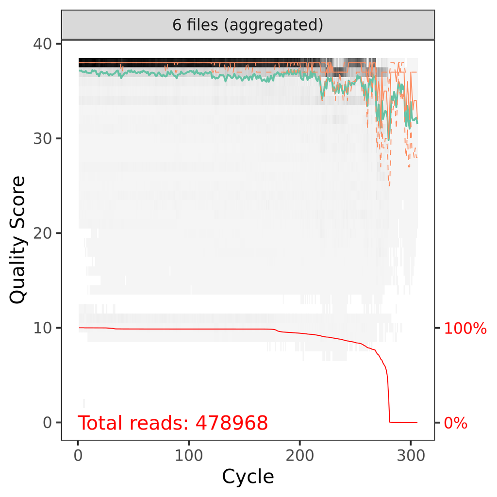

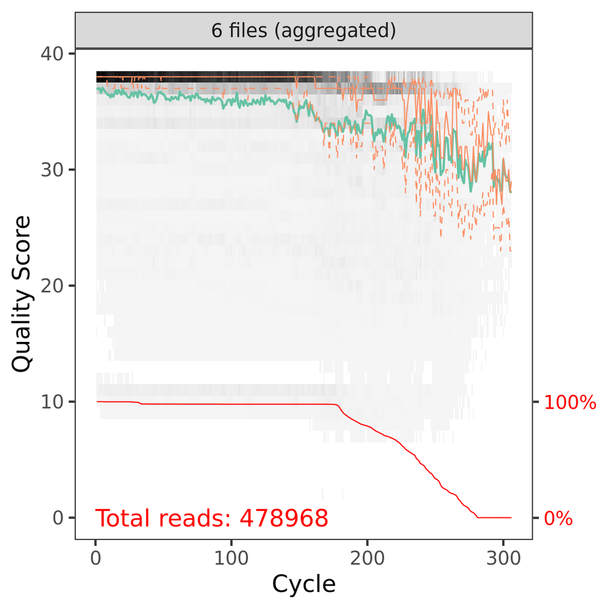

And after trimming it was:

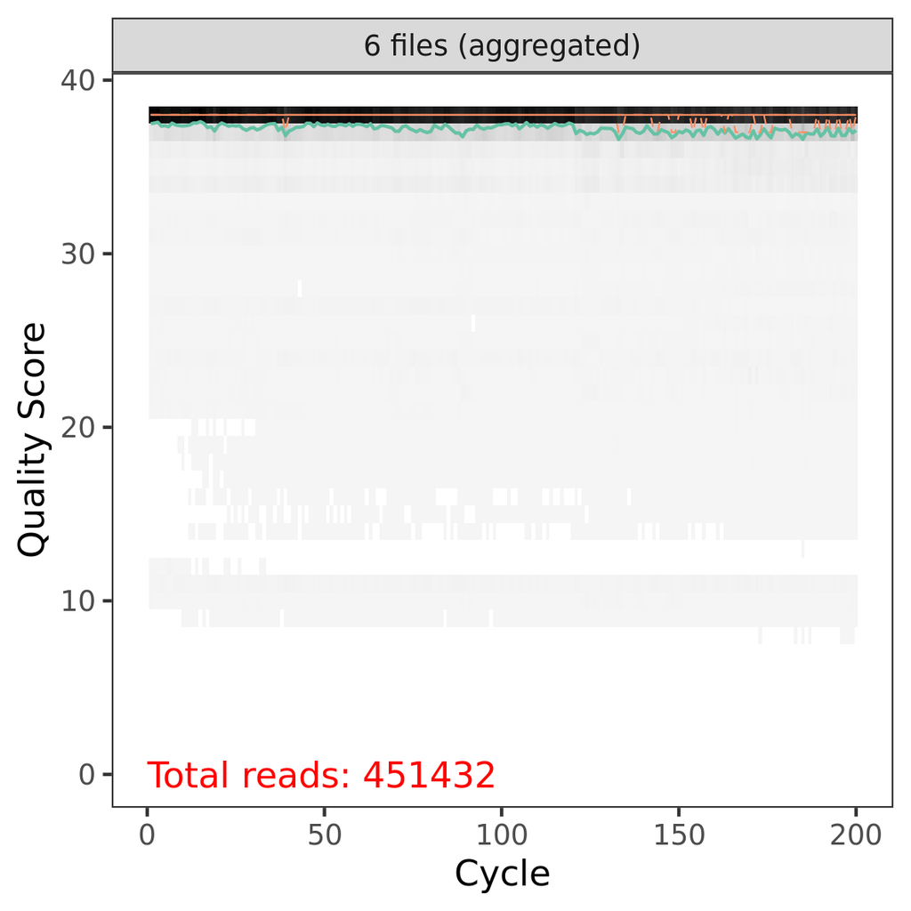

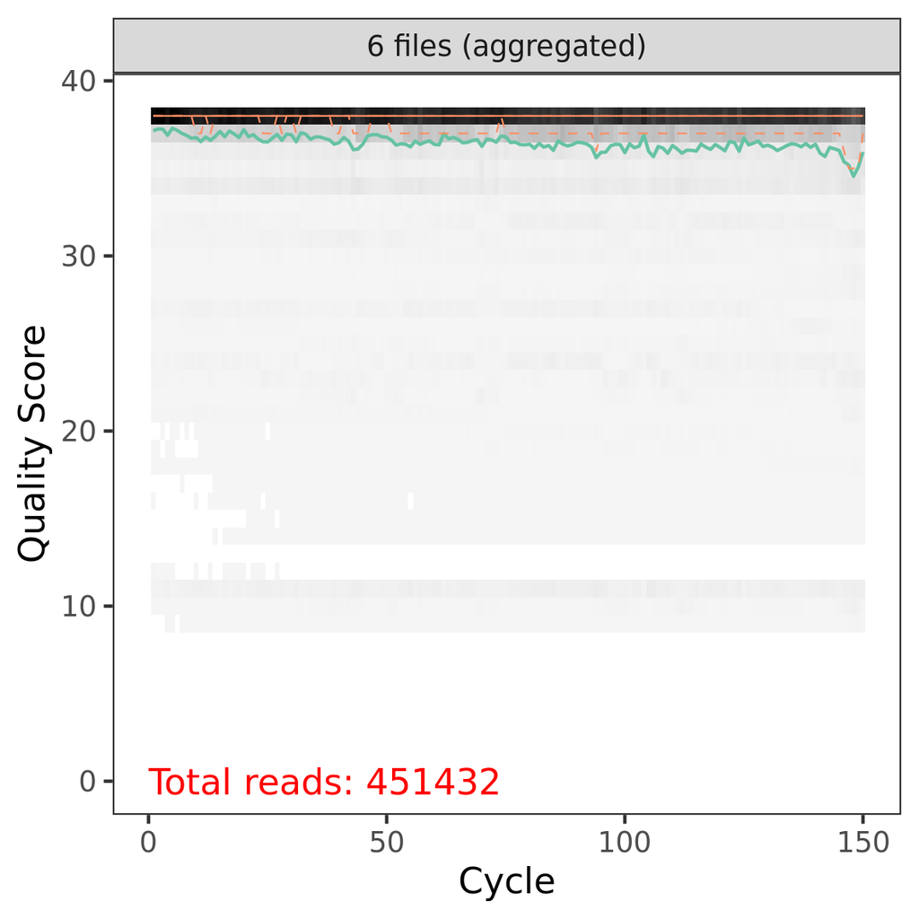

In case unpaired reads were kept after trimming and primer removal, quality profiles for unpaired reads can also be found in:

```
## ../../results/ARMS/runs/Blast_trials3/06-report/dada2/aggregate_quality_profiles_filesForw_single.png
```

```
## ../../results/ARMS/runs/Blast_trials3/06-report/dada2/aggregate_quality_profiles_filesRev_single.png
```

```
## ../../results/ARMS/runs/Blast_trials3/06-report/dada2/aggregate_quality_profiles_filtered_unpaired_forward.png
```

```
## ../../results/ARMS/runs/Blast_trials3/06-report/dada2/aggregate_quality_profiles_fitlered_unpaired_reverse.png
```

### 1.4.2 Asv inference

The following step of the dada2 pipeline was define the ASVs from these trimmed reads.  
First error rates were learned for both forward and reverse paired reads separately as well as any unpaired remaining reads which survived filtering, with the following command:

```
## learnErrors(filtFs, multithread = TRUE, nbases = 1e8, randomize = FALSE,MAX_CONSIST = 10, OMEGA_C = 0, verbose = FALSE)
```

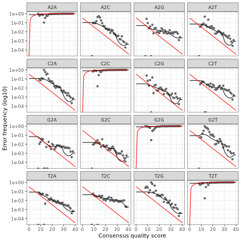

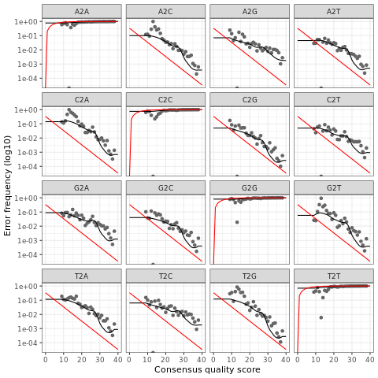

Next the reads were dereplicated with the following command:

```
## derepFastq(filtFs, n = 1e6)
```

The error rates were then used to infer ASVs from the dereplicated sequences using the following command for both forward and reverse reads separately:

```
## dada(derepFs, err = errF, selfConsist = FALSE, pool = FALSE, priors = ,
##   multithread = TRUE)
```

In case reads were overlapping (include merge in the config file), sequence pairs were combined using:

```
## mergePairs(dadaFs, derepFs, dadaRs, derepRs,
##   minOverlap = 12, maxMismatch = 0, returnRejects = FALSE,
##   propagateCol = , justConcatenate = FALSE, trimOverhang = FALSE)
```

If returnRejects was selected, also the returned unpaired sequences were kept in the final tables. Otherwise, the dereplicated sequences were kept without merging. Also any sequences unpaired forward or reverse sequences were added to the sequence tables at this stage. All single reverse sequences (unpaired either in trimmomatic or here, or if pairs were not merged), were reverse complemented for the bowtie2 algorithm.

And finally, chimeras were removed with:

```
## removeBimeraDenovo(seqtab, method = consensus, multithread = TRUE)
```

The amount of reads analysed in each step and remaining at the end of the pipeline were:

|  | reads.in | reads.out.paired | reads.in.forward.single | reads.out.forward.single | denoisedF | denoisedR | merged | denoisedF_single | nonchim | ASVs |
| --- | --- | --- | --- | --- | --- | --- | --- | --- | --- | --- |
| ERR3460466 | 106914 | 104073 | 25917 | 76 | 103787 | 102996 | 101720 | 58 | 93353 | 247 |
| ERR3460467 | 58538 | 52088 | 205722 | 9 | 51836 | 51565 | 51122 | 4 | 48066 | 147 |
| ERR3460468 | 69107 | 65261 | 117195 | 119 | 64809 | 64515 | 63773 | 77 | 60363 | 446 |
| ERR3460469 | 111881 | 108142 | 24368 | 160 | 106788 | 105991 | 103302 | 141 | 93910 | 946 |
| ERR3460470 | 123006 | 120298 | 23296 | 80 | 119733 | 119380 | 117481 | 48 | 117348 | 375 |
| ERR3460471 | 9522 | 1570 | 167688 | 0 | 1528 | 1512 | 1507 | NA | 1507 | 4 |

## 1.5 Assigning taxonomy

Next, taxonomy was assigned to the inferred reads. The sequences were aligned to the provided reference database using bowtie2. Because of this the bowtie2 database was also built (if not already provided), from the reference sequences.

The command used for the alignment was the following:

```
## bowtie2 -x bowtie2-database -f -U representative_seqs -S alignment.sam --no-hd --no-sq --very-sensitive --local --no-unal -p 3 -k 100 --un rejects.fasta
```

The best distinct alignments (parameter -k), were then used to infer the taxonomy based on a bayesian least common ancestor method. In this method, a higher taxonomy is assigned, if it shared enough times in the alignments made in the first step.

For this step the user defines the cutoff value used for accepting a taxonomic assignment (what is the likelihood that it is correct based on the 100 alignments made).

The used command was the following:

```
## python ./workflow/scripts/blca_from_bowtie.py  -i alignment.sam  -r data/databases/midori/MIDORI_UNIQ_SP_NUC_GB246_CO1_QIIME.taxon  -q data/databases/midori/MIDORI_UNIQ_SP_NUC_GB246_CO1_QIIME.fasta -b 0.8 -l 0.8  -n 100  -m 1 -f -2.5  -g -2 -o blca.output
```

The provided **cutoff** was then used to filter the blca output for reliable taxonomic assignments:

```
## python ./workflow/scripts/reformat_summary_for_r.py blca.output tax.table   100
```

A phyloseq object was built with this information, and can be found here:

./results/ARMS/runs/Blast_trials3/05-dwca/phyloseq_object.rds

The total information stored in the phyloseq object is:

```
## phyloseq-class experiment-level object
## otu_table()   OTU Table:         [ 1733 taxa and 6 samples ]
## sample_data() Sample Data:       [ 6 samples by 28 sample variables ]
## tax_table()   Taxonomy Table:    [ 1733 taxa by 12 taxonomic ranks ]
```

Note also that the sequences of the ASVs are stored in the tax_table of the phyloseq object.  
The total number of taxa assigned at each taxonomic level:

```
## kingdom  phylum   class   order  family   genus species
##    1733    1733    1733    1733    1733    1733    1733
```

In relative abundance (see total number of reads in the dada2 output), the most abundant taxa at phylumn level and at species level are shown in the following images.

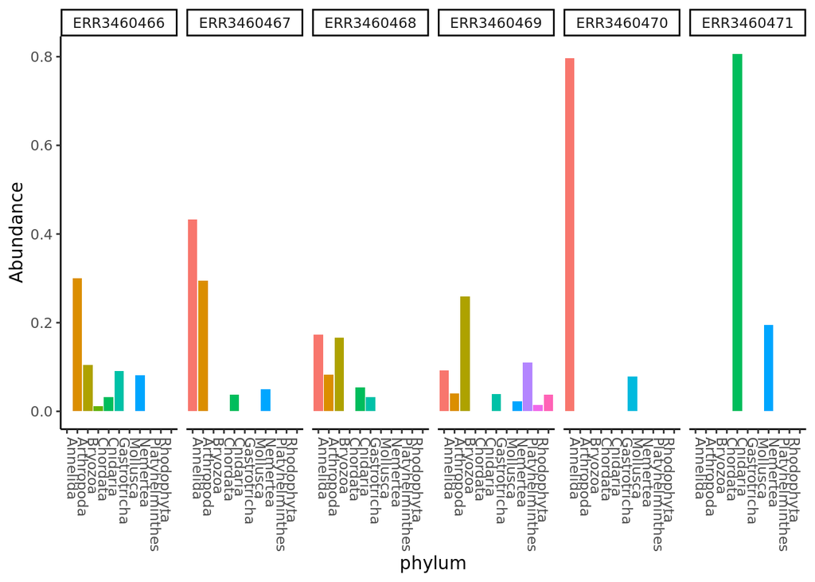

```r
pseq_rel<- transform_sample_counts(pseq, function(x) x / sum(x) )
pmelt<- psmelt(pseq_rel)

pmelt%>%
  group_by(phylum) %>%
  filter(Abundance > 0.01) %>%
  ggplot(aes(phylum, y=Abundance, fill=phylum))+
  geom_bar(stat='identity')+
  theme_classic()+
  theme(axis.text.x = element_text(angle = -90, hjust = 0), legend.position = 'none')+
  facet_grid(~Sample)
```

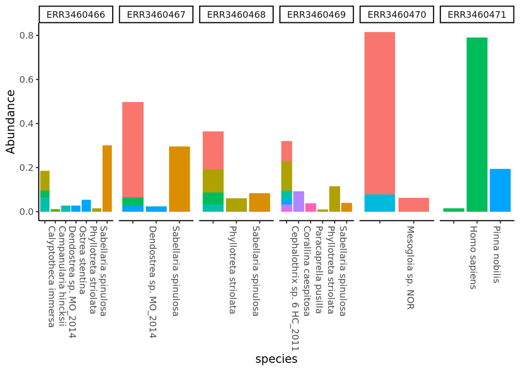

```r
pmelt %>%
  group_by(species) %>%
  filter(Abundance > 0.01) %>%
  ggplot(aes(species, y=Abundance, fill=phylum))+
  geom_bar(stat='identity')+
  theme_classic()+
  theme(axis.text.x = element_text(angle = -90, hjust = 0), legend.position = 'none')+
  facet_grid(~Sample, scales='free_x')
```

The relationship of the biodiversity between the samples is shown in the following ordination. The closer together the samples are depicted, the more similar the biodiversity measured in each of the samples was.

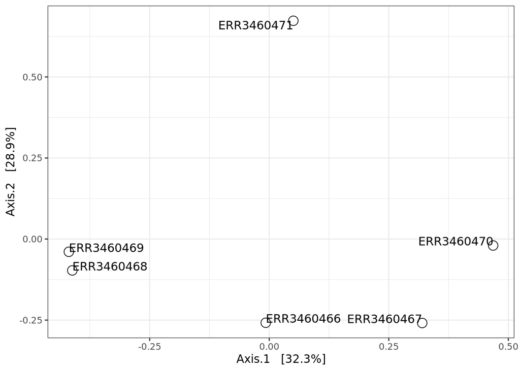

## 1.6 Darwin core archive tables

Finally, the results of this analysis were collected in a Darwin Core Occurrence table and DNA-derived data extension, to facilitate submitting the data to OBIS.

First, lsids for the assigned taxa were collected based on names in the WoRMS database. Occurrences that are not included in the final tables are mostly known taxa that are not marine. These occurrences are listed in the table 05-dwca/Taxa_not_in_worms.csv. This table also potentially has marine species that are not recognized by WoRMS yet, and therefore it is recommended to manually review this table.

All unknown sequences that did not have a taxonomic assignment are added in the occurrence table as ‘Biota’, however in the future more checks will be made to filter out sequences that were not from the target gene region or are likely not marine.

In addition, if there was a control sample which was labelled in the original sample as OccurrenceStatus; “absent”, any occurrences of the taxa found in this sample were removed from all samples.

The final tables can be found at:

results/ARMS/runs/Blast_trials3/05-dwca/Occurrence_table.csv  
results/ARMS/runs/Blast_trials3/05-dwca/DNA_extension_table.csv

The total number of occurrences was 2066 .  
Of which 1372 were known, and therefore 694 or 33.59148 % remained unknown.

The sequences of these occurrences can nevertheless be added to the database, and it is possible that their taxonomy will be defined when reference databases develop.

The number of names not found in the marine records of WoRMS was 720